# comparison with different number of measurements per site

Karina Cucchi

May 6 2018

In this script I compare the regionalized prior for a different number of measurements per site. We consider 2 sites only. J_1 is the number of measurements at site S1. J_2 is the number of measurements at site S2. We use KLD between an uninformative prior and the derived regionalized prior as a measure of information gain. KLD_1 is the gain in information using site S1 only. KLD_2 is the gain in information using site S2 only. KLD_12 is the gain in information using sites S1 and S2. KLD_same is the gain in information using information from both sites, but ignoring inter-site variability (i.e. considering that all measurements come from the same site). a is KLD_1/KLD_12. b is KLD_2/KLD_12.

```r
library(ggplot2)

df_res <- readRDS(file = 'df_res_sec3.1.2.rds')

# View(df_res)

# select rows without NAs only
df_res <- subset(x = df_res,subset = !is.na(KLD_1))
```

# first plot distribution for J_1=2 and J_2=5 only

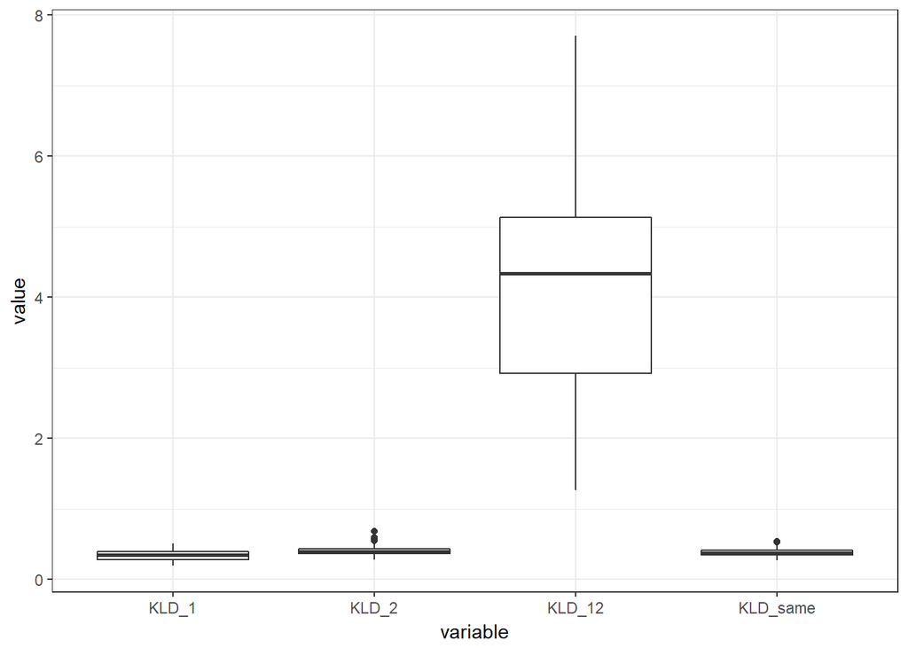

```r
df_res_subset <- subset(x = df_res,
                        subset = (J_1 == 2 & J_2 == 5))

# df_res_subset

# switch to long format
df_res_subset_long <-
  reshape2::melt(data = df_res_subset,
                 id = c("J_1","J_2", "real_idx", "S_idx1", "S_idx2","simu_idx"))

# ggplot(df_res_subset_long) +
#   geom_density(mapping = aes(x = value,fill=variable),alpha=0.5) +
#   theme_bw()


ggplot(subset(df_res_subset_long,variable %in% c('KLD_1','KLD_2','KLD_12','KLD_same'))) +
  geom_boxplot(mapping = aes(x = variable,y=value)) +
  theme_bw()
```

This figure shows that the gain in information is always much higher when using 2 sites instead of 1. KLD_1, KLD_2, and KLD_same are on the same order of magnitude.

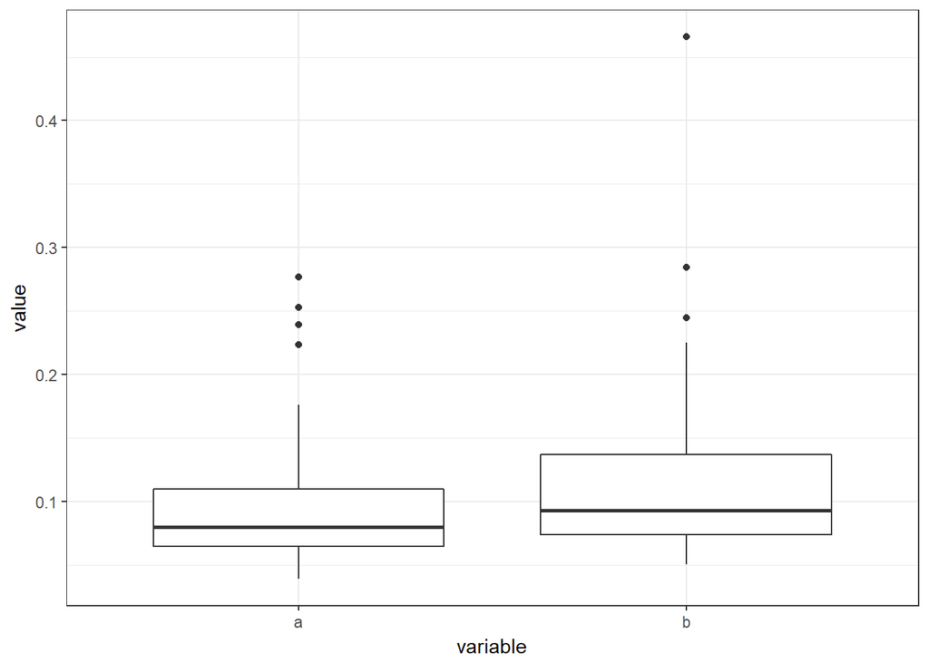

```r
# ggplot(subset(df_res_subset_long,variable %in% c('a','b'))) +
#   geom_density(mapping = aes(x = value,fill=variable),alpha=0.5) +
#   theme_bw()

ggplot(subset(df_res_subset_long,variable %in% c('a','b'))) +
  geom_boxplot(mapping = aes(x = variable,y=value)) +
  theme_bw()
```

This figure compares the distribution of a = KLD_1/KLD_12 and b = KLD_2/KLD_12. The first observation is that, on average, b is higher than a. This suggests that the regionalized prior algorithm recognizes that site S_2 (containing 5 measurements) contains on average more information than site S_1 (containing 2 measurements). The second observation is that the distributions of a and b largely overlap. This suggests that adding measurements at a given site leads to second order improvements when compared to adding a new site.

# Now try visualisations as a function of J_1

Second, we investigate the sensitivity of the results to varying number of measurements at site S_1.

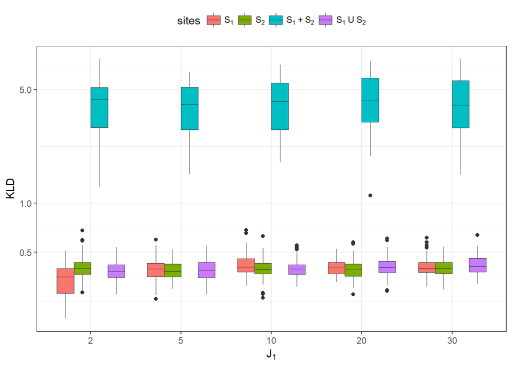

```r
df_res_long <-
  reshape2::melt(data = df_res,
                 id = c("J_1","J_2", "real_idx", "S_idx1", "S_idx2","simu_idx"))

# ggplot(data = subset(df_res_long,
#                      subset = variable %in% c('KLD_1','KLD_2','KLD_12','KLD_same'))) +
#   geom_boxplot(mapping = aes(x = variable,y=value)) +
#   facet_grid(J_2 ~ J_1,labeller = label_both) +
#   theme_bw()

g_compare <-
  ggplot(data = subset(df_res_long,
                       subset = variable %in% c('KLD_1','KLD_2','KLD_12','KLD_same') &
                         J_2 == 5)) +
  geom_boxplot(mapping = aes(x = factor(J_1),y=value,fill=factor(variable)),
               lwd=0.1) +
  scale_y_continuous(breaks=c(0.1,0.5,1,5,10),
                     trans = "log10") +
  scale_fill_discrete(labels=c('KLD_1'=bquote('S'['1']),
                               'KLD_2'=bquote('S'['2']),
                               'KLD_12'=bquote('S'['1'] *' + S'['2']),
                               'KLD_same'=bquote('S'['1'] *' U S'['2']))) +
  labs(x=bquote('J'['1']),y='KLD',fill='sites') +
  # facet_grid(J_2 ~ J_1,labeller = label_both) +
  theme_bw() +
  theme(legend.position = 'top')

g_compare
```

```r
pdf(file = 'g_all_312.pdf',width = 4,height = 3)
print(g_compare)
dev.off()
```

```r
saveRDS(object = g_compare,file = 'g_all_312.rds')
```

The KLD is much higher for S1+S2 than for the other configurations, and this is valid for all values of J_1. This suggests that there is more information to be gained by assimilating measurements from different sites, than by adding more measurements at the same site, as the KLD showed little sensitivity to the number of measurements per site for all values of J_1.